# Dərs 4: Bərabərləşdirmə Üçün Dizayn Metodları

Təhsildə Test Nəticələrinin Bərabərləşdirilməsi - R Proqram Dili ilə

Test Bərabərləşdirmə Kursu

2025-07-15

# 1 Bərabərləşdirmə Üçün Dizayn Metodları

## 1.1 Dərsin Məqsədləri

Bu dərsin sonunda siz:

✅ Müxtəlif bərabərləşdirmə dizayn metodlarını tanıyacaqsınız  
✅ Təsadüfi qruplar, ümumi maddə və ümumi şəxs dizaynlarını fərqləndirəcəksiniz  
✅ Hər dizaynın üstün və zəif tərəflərini qiymətləndirə biləcəksiniz  
✅ Real ssenarilər üçün uyğun dizayn seçə biləcəksiniz  
✅ R-də müxtəlif dizaynları simulyasiya edə biləcəksiniz

## 1.2 Bərabərləşdirmə Dizaynlarına Ümumi Baxış

### 1.2.1 Dizayn Nədir və Niyə Vacibdir?

**Bərabərləşdirmə dizaynı** - iki və ya daha çox test formasından məlumat toplamaq üçün istifadə olunan strategiyadır. Bu strategiya test nəticələrinin necə əlaqələndiriləcəyini müəyyən edir.

Düzgün dizayn seçimi aşağıdakıları təmin edir:

- 🎯 **Etibarlılıq**: Sabit və dəqiq nəticələr
- ⚖️ **Validlik**: Ədalətli müqayisələr
- 🔧 **Praktiklik**: Real şəraitdə tətbiq olunma qabiliyyəti
- 💰 **İqtisadlıq**: Resurs və vaxt qənaəti

### 1.2.2 Əsas Dizayn Növləri

Bərabərləşdirmə Dizayn Növlərinin Müqayisəsi

| Dizayn.Növü | İngilis.Adı | Əsas.Xüsusiyyəti | Tətbiq.Sahəsi | Çətinlik |
| --- | --- | --- | --- | --- |
| Təsadüfi Qruplar | Random Groups | Müxtəlif testlər müxtəlif qruplara verilir | Böyük miqyaslı testlər | Asan |
| Ümumi Maddə | Common Item | Testlər arasında ortaq maddələr olur | Standart testlər | Orta |
| Ümumi Şəxs | Common Person | Eyni şəxslər müxtəlif testlər verir | Təhlükəsizlik tədbirləri | Çətin |
| Qarışıq (NEAT) | Mixed/NEAT | Müxtəlif dizaynların kombinasiyası | Kompleks tədqiqatlar | Çox çətin |

## 1.3 R Mühitinin Hazırlanması

### 1.3.1 Paketlərin Yüklənməsi

```r
# Paketləri aktivləşdirin
suppressMessages({
  library(equate)      # Test bərabərləşdirmə metodları
  library(kequate)     # Kernel metodlar
  library(ggplot2)     # Qrafik vizuallaşdırma
  library(dplyr)       # Məlumat manipulyasiyası
  library(knitr)       # Cədvəl formatlaşdırması
  library(gridExtra)   # Qrafik təşkili
})

# Qrafik təmas
theme_set(theme_minimal(base_size = 12))
colors_custom <- c("#3498db", "#e74c3c", "#2ecc71", "#f39c12", "#9b59b6")

cat("✅ R mühiti uğurla konfiqurasiya edildi!\n")
```

```
## ✅ R mühiti uğurla konfiqurasiya edildi!
```

### 1.3.2 Ümumi Funksiyalar

```r
# Lineer bərabərləşdirmə funksiyası
linear_equating <- function(x_scores, y_scores) {
  mean_x <- mean(x_scores)
  mean_y <- mean(y_scores)
  sd_x <- sd(x_scores)
  sd_y <- sd(y_scores)

  slope <- sd_y / sd_x
  intercept <- mean_y - slope * mean_x

  return(list(
    slope = slope,
    intercept = intercept,
    mean_x = mean_x,
    mean_y = mean_y,
    sd_x = sd_x,
    sd_y = sd_y
  ))
}

# Sürətli statistika funksiyası
quick_stats <- function(scores, name = "Test") {
  list(
    name = name,
    n = length(scores),
    mean = round(mean(scores), 2),
    sd = round(sd(scores), 2),
    min = min(scores),
    max = max(scores)
  )
}

cat("✅ Yardımçı funksiyalar hazırlanıldı!\n")
```

```
## ✅ Yardımçı funksiyalar hazırlanıldı!
```

# 2 Təsadüfi Qruplar Dizaynı (Random Groups Design)

## 2.1 Metodun Əsasları

Təsadüfi qruplar dizaynında **müxtəlif test formaları təsadüfi olaraq müxtəlif şagird qruplarına verilir**. Bu metodun əsas fərzi odur ki, qruplar arasında ortalama qabiliyyət fərqi yoxdur.

### 2.1.1 Üstünlükləri və Çatışmazlıqları

Təsadüfi Qruplar Dizaynının Xüsusiyyətləri

| Aspekt | Qiymət | Şərh |
| --- | --- | --- |
| Test Təhlükəsizliyi | Yüksək ⭐⭐⭐ | Eyni şəxs müxtəlif testlər görmür |
| Vaxt Səmərəliliyi | Yüksək ⭐⭐⭐ | Hər şəxs yalnız bir test verir |
| Nümunə Ölçüsü Tələbi | Böyük ❌ | Böyük nümunə ölçüsü lazımdır |
| Statistik Dəqiqlik | Orta ⭐⭐ | Qrup fərqlərindən asılıdır |
| Praktik Tətbiq | Asan ⭐⭐⭐ | Sadə və praktik tətbiq |
| Məlumat Keyfiyyəti | Orta ⭐⭐ | Təsadüfi təyinata asılıdır |

## 2.2 R-də Simulyasiya

### 2.2.1 Test Məlumatlarının Yaradılması

```r
# Təsadüfi qruplar dizaynı simulyasiyası
set.seed(123)

# Ümumi şagird sayı və qabiliyyət paylanması
total_students <- 2000
student_abilities <- rnorm(total_students, mean = 0, sd = 1)

# Şagird məlumatlarını yaradın
students_data <- data.frame(
  student_id = 1:total_students,
  ability = student_abilities,
  # Təsadüfi qrup təyinatı (50-50 bölgü)
  assigned_form = sample(c("Form_A", "Form_B"), total_students,
                        replace = TRUE, prob = c(0.5, 0.5))
)

# Test formalarının parametrlərini təyin edin
form_A_difficulty <- 0.0     # Baza çətinlik
form_A_discrimination <- 1.0
form_B_difficulty <- -0.2    # Bir az asanlaşıb
form_B_discrimination <- 1.1

# Test nəticələrini hesablayın (IRT modelinə əsasən)
calculate_test_score <- function(ability, difficulty, discrimination, n_items = 50) {
  prob_correct <- 1 / (1 + exp(-discrimination * (ability - difficulty)))
  raw_score <- rbinom(1, n_items, prob_correct)
  scaled_score <- round((raw_score / n_items) * 100, 0)
  return(scaled_score)
}

# Hər şagird üçün test balını hesablayın
students_data$test_score <- mapply(
  function(ability, form) {
    if (form == "Form_A") {
      calculate_test_score(ability, form_A_difficulty, form_A_discrimination)
    } else {
      calculate_test_score(ability, form_B_difficulty, form_B_discrimination)
    }
  },
  students_data$ability,
  students_data$assigned_form
)

# Qrupları ayırın
group_A <- students_data[students_data$assigned_form == "Form_A", ]
group_B <- students_data[students_data$assigned_form == "Form_B", ]

cat("=== Təsadüfi Qruplar Dizaynı Nəticələri ===\n")
```

```
## === Təsadüfi Qruplar Dizaynı Nəticələri ===
```

```r
cat("Form A - Şagird sayı:", nrow(group_A), "\n")
```

```
## Form A - Şagird sayı: 982
```

```r
cat("Form A - Ortalama bal:", round(mean(group_A$test_score), 2), "\n")
```

```
## Form A - Ortalama bal: 49.69
```

```r
cat("Form A - Standart sapma:", round(sd(group_A$test_score), 2), "\n\n")
```

```
## Form A - Standart sapma: 21.81
```

```r
cat("Form B - Şagird sayı:", nrow(group_B), "\n")
```

```
## Form B - Şagird sayı: 1018
```

```r
cat("Form B - Ortalama bal:", round(mean(group_B$test_score), 2), "\n")
```

```
## Form B - Ortalama bal: 56
```

```r
cat("Form B - Standart sapma:", round(sd(group_B$test_score), 2), "\n")
```

```
## Form B - Standart sapma: 22.87
```

### 2.2.2 Qabiliyyət Validasiyası

```r
# Qabiliyyət baxımından qrupları müqayisə edin (DİZAYN KEYFİYYƏTİ YOXLAMASI)
cat("\n=== Qabiliyyət Müqayisəsi (Validasiya) ===\n")
```

```
##
## === Qabiliyyət Müqayisəsi (Validasiya) ===
```

```r
cat("Form A - Ortalama qabiliyyət:", round(mean(group_A$ability), 3), "\n")
```

```
## Form A - Ortalama qabiliyyət: -0.005
```

```r
cat("Form B - Ortalama qabiliyyət:", round(mean(group_B$ability), 3), "\n")
```

```
## Form B - Ortalama qabiliyyət: 0.063
```

```r
cat("Qabiliyyət fərqi:", round(mean(group_A$ability) - mean(group_B$ability), 3), "\n")
```

```
## Qabiliyyət fərqi: -0.068
```

```r
# Statistik test
ability_test <- t.test(group_A$ability, group_B$ability)
cat("t-test p-value:", round(ability_test$p.value, 4), "\n")
```

```
## t-test p-value: 0.1306
```

```r
if (ability_test$p.value > 0.05) {
  cat("✅ Qruplar arasında məna fərqi YOX (yaxşı dizayn)\n")
  design_quality_rg <- "Yaxşı"
} else {
  cat("❌ Qruplar arasında məna fərqi VAR (problemli dizayn)\n")
  design_quality_rg <- "Problemli"
}
```

```
## ✅ Qruplar arasında məna fərqi YOX (yaxşı dizayn)
```

```r
# Effect size hesablaması
cohens_d <- (mean(group_A$ability) - mean(group_B$ability)) /
            sqrt((var(group_A$ability) + var(group_B$ability)) / 2)
cat("Cohen's d (effect size):", round(cohens_d, 3), "\n")
```

```
## Cohen's d (effect size): -0.068
```

### 2.2.3 Bərabərləşdirmə və Transformasiya

```r
# Bərabərləşdirmə (Form B → Form A)
eq_params_rg <- linear_equating(group_B$test_score, group_A$test_score)

cat("\n=== Təsadüfi Qruplar Lineer Bərabərləşdirmə ===\n")
```

```
##
## === Təsadüfi Qruplar Lineer Bərabərləşdirmə ===
```

```r
cat("Slope (b):", round(eq_params_rg$slope, 4), "\n")
```

```
## Slope (b): 0.9537
```

```r
cat("Intercept (a):", round(eq_params_rg$intercept, 2), "\n")
```

```
## Intercept (a): -3.72
```

```r
# Bərabərləşdirmə funksiyası
equate_score_rg <- function(x) {
  return(eq_params_rg$intercept + eq_params_rg$slope * x)
}

# Nümunə transformasiyalar
sample_scores_b <- c(60, 70, 80, 90, 95)
equated_scores <- equate_score_rg(sample_scores_b)

transformation_table_rg <- data.frame(
  "Form B Balı" = sample_scores_b,
  "Form A Ekvivalenti" = round(equated_scores, 1),
  "Düzəliş" = round(equated_scores - sample_scores_b, 1)
)

kable(transformation_table_rg,
      caption = "Təsadüfi Qruplar Bərabərləşdirmə Nümunələri",
      align = c("c", "c", "c"))
```

Təsadüfi Qruplar Bərabərləşdirmə Nümunələri

| Form.B.Balı | Form.A.Ekvivalenti | Düzəliş |
| --- | --- | --- |
| 60 | 53.5 | -6.5 |
| 70 | 63.0 | -7.0 |
| 80 | 72.6 | -7.4 |
| 90 | 82.1 | -7.9 |
| 95 | 86.9 | -8.1 |

### 2.2.4 Vizuallaşdırma

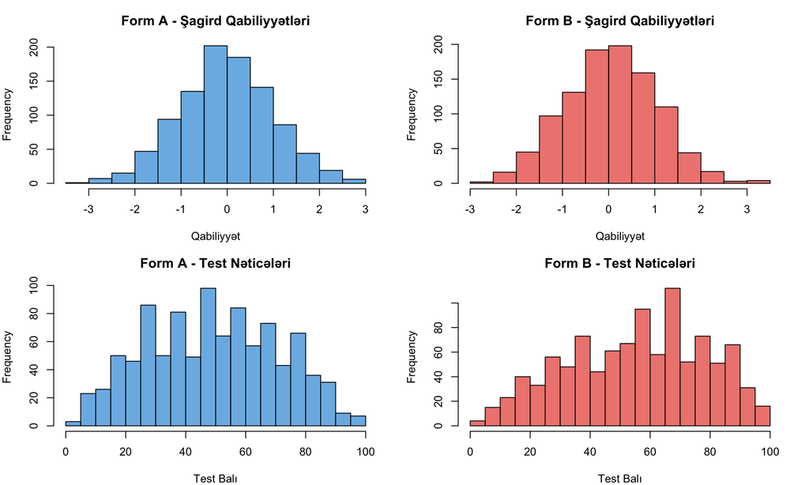

Təsadüfi Qruplar Dizaynının Vizual Təhlili

```r
# Çoxşəkilli vizuallaşdırma
par(mfrow = c(2, 2), mar = c(4, 4, 3, 2))

# 1. Qabiliyyət paylanması
hist(group_A$ability, breaks = 20, col = adjustcolor(colors_custom[1], alpha.f = 0.7),
     main = "Form A - Şagird Qabiliyyətləri", xlab = "Qabiliyyət")
hist(group_B$ability, breaks = 20, col = adjustcolor(colors_custom[2], alpha.f = 0.7),
     main = "Form B - Şagird Qabiliyyətləri", xlab = "Qabiliyyət")

# 2. Test nəticələri paylanması
hist(group_A$test_score, breaks = 20, col = adjustcolor(colors_custom[1], alpha.f = 0.7),
     main = "Form A - Test Nəticələri", xlab = "Test Balı")
hist(group_B$test_score, breaks = 20, col = adjustcolor(colors_custom[2], alpha.f = 0.7),
     main = "Form B - Test Nəticələri", xlab = "Test Balı")
```

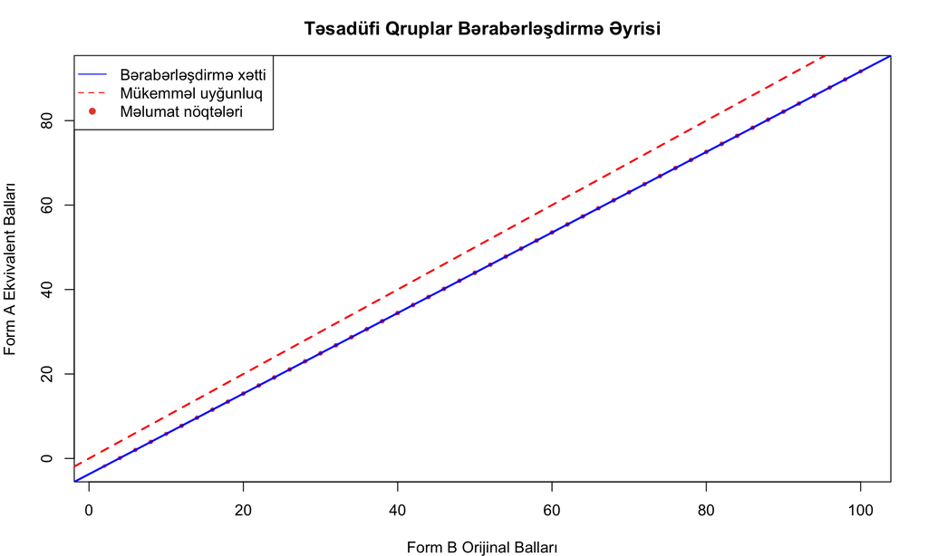

Təsadüfi Qruplar Dizaynının Vizual Təhlili

```r
# 3. Bərabərləşdirmə əyrisi
par(mfrow = c(1, 1))
plot(group_B$test_score, equate_score_rg(group_B$test_score),
     xlab = "Form B Orijinal Balları", ylab = "Form A Ekvivalent Balları",
     main = "Təsadüfi Qruplar Bərabərləşdirmə Əyrisi",
     col = adjustcolor(colors_custom[2], alpha.f = 0.6), pch = 16, cex = 0.6)
abline(0, 1, col = "red", lty = 2, lwd = 2)
abline(eq_params_rg$intercept, eq_params_rg$slope, col = "blue", lwd = 2)
legend("topleft",
       c("Bərabərləşdirmə xətti", "Mükemməl uyğunluq", "Məlumat nöqtələri"),
       col = c("blue", "red", colors_custom[2]),
       lty = c(1, 2, NA), pch = c(NA, NA, 16))
```

# 3 Ümumi Maddə Dizaynı (Common Item Design)

## 3.1 Metodun Əsasları

Ümumi maddə dizaynında **iki test arasında ortaq maddələr** mövcuddur. Bu ortaq maddələr “körpü” rolunu oynayaraq testlər arasında əlaqə yaradır.

### 3.1.1 Dizayn Variantları

Ümumi Maddə Dizaynının Variantları

| Variant | Ortaq.Maddələr | Üstünlük | Çatışmazlıq |
| --- | --- | --- | --- |
| Internal Anchor | Ümumi bala daxildir | Sadə hesablama | Bias riski |
| External Anchor | Ayrıca hesablanır | Ayrıca validasiya | Mürəkkəb analiz |
| Embedded Anchor | Gizli şəkildə daxildir | Test təhlükəsizliyi | Müdaxilə effekti |

## 3.2 R-də Simulyasiya

### 3.2.1 Test Strukturunun Yaradılması

```r
# Ümumi maddə dizaynı simulyasiyası
set.seed(456)

# Test strukturu
common_items <- 15      # Ortaq maddələr
unique_A_items <- 35    # Form A-ya məxsus maddələr
unique_B_items <- 30    # Form B-yə məxsus maddələr

total_A_items <- common_items + unique_A_items  # 50 maddə
total_B_items <- common_items + unique_B_items  # 45 maddə

# Şagird qabiliyyətləri
n_students_ci <- 1200
abilities_ci <- rnorm(n_students_ci, mean = 0, sd = 1)

cat("=== Ümumi Maddə Dizaynı Strukturu ===\n")
```

```
## === Ümumi Maddə Dizaynı Strukturu ===
```

```r
cat("Ortaq maddələr:", common_items, "\n")
```

```
## Ortaq maddələr: 15
```

```r
cat("Form A unikal maddələr:", unique_A_items, "\n")
```

```
## Form A unikal maddələr: 35
```

```r
cat("Form B unikal maddələr:", unique_B_items, "\n")
```

```
## Form B unikal maddələr: 30
```

```r
cat("Form A cəmi maddələr:", total_A_items, "\n")
```

```
## Form A cəmi maddələr: 50
```

```r
cat("Form B cəmi maddələr:", total_B_items, "\n")
```

```
## Form B cəmi maddələr: 45
```

```r
cat("Ümumi şagird sayı:", n_students_ci, "\n")
```

```
## Ümumi şagird sayı: 1200
```

### 3.2.2 IRT Parametrləri və Cavab Generasiyası

```r
# Maddə parametrlərini yaradın
# Ortaq maddələr (hər iki testdə eyni)
common_difficulties <- rnorm(common_items, mean = 0, sd = 0.8)
common_discriminations <- rlnorm(common_items, meanlog = 0, sdlog = 0.3)

# Form A unikal maddələri
unique_A_difficulties <- rnorm(unique_A_items, mean = -0.1, sd = 0.9)
unique_A_discriminations <- rlnorm(unique_A_items, meanlog = 0, sdlog = 0.3)

# Form B unikal maddələri
unique_B_difficulties <- rnorm(unique_B_items, mean = 0.1, sd = 0.9)
unique_B_discriminations <- rlnorm(unique_B_items, meanlog = 0, sdlog = 0.3)

# Test parametrlərini birləşdirin
form_A_difficulties <- c(common_difficulties, unique_A_difficulties)
form_A_discriminations <- c(common_discriminations, unique_A_discriminations)

form_B_difficulties <- c(common_difficulties, unique_B_difficulties)
form_B_discriminations <- c(common_discriminations, unique_B_discriminations)

# Test cavablarını yaradın
generate_responses <- function(ability, difficulties, discriminations) {
  n_items <- length(difficulties)
  responses <- numeric(n_items)

  for (i in 1:n_items) {
    prob <- 1 / (1 + exp(-discriminations[i] * (ability - difficulties[i])))
    responses[i] <- rbinom(1, 1, prob)
  }

  return(responses)
}

# Hər şagird üçün hər iki testdə cavablar yaradın
form_A_responses <- matrix(NA, n_students_ci, total_A_items)
form_B_responses <- matrix(NA, n_students_ci, total_B_items)

for (i in 1:n_students_ci) {
  form_A_responses[i, ] <- generate_responses(abilities_ci[i],
                                            form_A_difficulties,
                                            form_A_discriminations)
  form_B_responses[i, ] <- generate_responses(abilities_ci[i],
                                            form_B_difficulties,
                                            form_B_discriminations)
}

# Balları hesablayın
form_A_total_scores <- rowSums(form_A_responses)
form_B_total_scores <- rowSums(form_B_responses)

# Ortaq maddə ballarını hesablayın
form_A_common_scores <- rowSums(form_A_responses[, 1:common_items])
form_B_common_scores <- rowSums(form_B_responses[, 1:common_items])

cat("\n=== Maddə Parametrləri Statistikaları ===\n")
```

```
##
## === Maddə Parametrləri Statistikaları ===
```

```r
cat("Ortaq maddələr ortalama çətinlik:", round(mean(common_difficulties), 3), "\n")
```

```
## Ortaq maddələr ortalama çətinlik: 0.342
```

```r
cat("Form A unikal ortalama çətinlik:", round(mean(unique_A_difficulties), 3), "\n")
```

```
## Form A unikal ortalama çətinlik: -0.04
```

```r
cat("Form B unikal ortalama çətinlik:", round(mean(unique_B_difficulties), 3), "\n")
```

```
## Form B unikal ortalama çətinlik: 0.233
```

### 3.2.3 Təsadüfi Qrup Təyinatı

```r
# Təsadüfi qruplar yaradın (hər şagird yalnız bir test verir)
group_assignment_ci <- sample(c("A", "B"), n_students_ci, replace = TRUE)

# Müşahidə olunan məlumatlar
observed_A <- which(group_assignment_ci == "A")
observed_B <- which(group_assignment_ci == "B")

cat("=== Müşahidə Olunan Məlumatlar ===\n")
```

```
## === Müşahidə Olunan Məlumatlar ===
```

```r
cat("Form A-nı verən şagirdlər:", length(observed_A), "\n")
```

```
## Form A-nı verən şagirdlər: 608
```

```r
cat("Form B-ni verən şagirdlər:", length(observed_B), "\n")
```

```
## Form B-ni verən şagirdlər: 592
```

```r
# Bal statistikaları
cat("\n=== Bal Statistikaları ===\n")
```

```
##
## === Bal Statistikaları ===
```

```r
cat("Form A - Ümumi bal ortalaması:", round(mean(form_A_total_scores[observed_A]), 2), "\n")
```

```
## Form A - Ümumi bal ortalaması: 25.06
```

```r
cat("Form B - Ümumi bal ortalaması:", round(mean(form_B_total_scores[observed_B]), 2), "\n")
```

```
## Form B - Ümumi bal ortalaması: 20.9
```

```r
cat("Form A - Ortaq maddə ortalaması:", round(mean(form_A_common_scores[observed_A]), 2), "\n")
```

```
## Form A - Ortaq maddə ortalaması: 6.84
```

```r
cat("Form B - Ortaq maddə ortalaması:", round(mean(form_B_common_scores[observed_B]), 2), "\n")
```

```
## Form B - Ortaq maddə ortalaması: 6.88
```

```r
# Ortaq maddələrin keyfiyyəti
common_correlation <- cor(form_A_common_scores, form_B_common_scores)
cat("Ortaq maddələr arasında korelasiya (bütün şagirdlər):", round(common_correlation, 3), "\n")
```

```
## Ortaq maddələr arasında korelasiya (bütün şagirdlər): 0.717
```

## 3.3 Zəncir Bərabərləşdirmə (Chain Equating)

### 3.3.1 Metodun Alqoritmi

Zəncir bərabərləşdirmə iki addımda həyata keçirilir:

1. **Addım 1**: Total A → Common A
2. **Addım 2**: Common B → Total B
3. **Kombinasiya**: Total A → Common A → Common B → Total B

```r
# Zəncir bərabərləşdirmə metodunu tətbiq edin
chain_equating <- function(total_A, total_B, common_A, common_B) {
  # Addım 1: Total A → Common A
  eq1 <- linear_equating(total_A, common_A)

  # Addım 2: Common B → Total B
  eq2 <- linear_equating(common_B, total_B)

  # Zəncir kombinasiyası: Total A → Common A → Common B → Total B
  # y = a₂ + b₂(a₁ + b₁x) = (a₂ + b₂a₁) + (b₂b₁)x
  chain_intercept <- eq2$intercept + eq2$slope * eq1$intercept
  chain_slope <- eq2$slope * eq1$slope

  return(list(
    slope = chain_slope,
    intercept = chain_intercept,
    step1 = eq1,
    step2 = eq2
  ))
}

# Zəncir bərabərləşdirmə (Form A → Form B)
chain_eq <- chain_equating(
  form_A_total_scores[observed_A],
  form_B_total_scores[observed_B],
  form_A_common_scores[observed_A],
  form_B_common_scores[observed_B]
)

cat("=== Zəncir Bərabərləşdirmə Nəticələri ===\n")
```

```
## === Zəncir Bərabərləşdirmə Nəticələri ===
```

```r
cat("Ümumi slope:", round(chain_eq$slope, 4), "\n")
```

```
## Ümumi slope: 0.925
```

```r
cat("Ümumi intercept:", round(chain_eq$intercept, 2), "\n\n")
```

```
## Ümumi intercept: -2.41
```

```r
cat("Addım 1 (Total A → Common A):\n")
```

```
## Addım 1 (Total A → Common A):
```

```r
cat("  Slope:", round(chain_eq$step1$slope, 4), "\n")
```

```
##   Slope: 0.3376
```

```r
cat("  Intercept:", round(chain_eq$step1$intercept, 2), "\n\n")
```

```
##   Intercept: -1.63
```

```r
cat("Addım 2 (Common B → Total B):\n")
```

```
## Addım 2 (Common B → Total B):
```

```r
cat("  Slope:", round(chain_eq$step2$slope, 4), "\n")
```

```
##   Slope: 2.74
```

```r
cat("  Intercept:", round(chain_eq$step2$intercept, 2), "\n")
```

```
##   Intercept: 2.05
```

```r
# Zəncir bərabərləşdirmə funksiyası
equate_score_chain <- function(x) {
  return(chain_eq$intercept + chain_eq$slope * x)
}

# Nümunə transformasiyalar
sample_scores_A <- seq(30, 50, 5)
chain_equated_scores <- equate_score_chain(sample_scores_A)

transformation_table_chain <- data.frame(
  "Form A Balı" = sample_scores_A,
  "Form B Ekvivalenti" = round(chain_equated_scores, 1),
  "Düzəliş" = round(chain_equated_scores - sample_scores_A, 1)
)

kable(transformation_table_chain,
      caption = "Zəncir Bərabərləşdirmə Nümunələri",
      align = c("c", "c", "c"))
```

Zəncir Bərabərləşdirmə Nümunələri

| Form.A.Balı | Form.B.Ekvivalenti | Düzəliş |
| --- | --- | --- |
| 30 | 25.3 | -4.7 |
| 35 | 30.0 | -5.0 |
| 40 | 34.6 | -5.4 |
| 45 | 39.2 | -5.8 |
| 50 | 43.8 | -6.2 |

### 3.3.2 Vizuallaşdırma

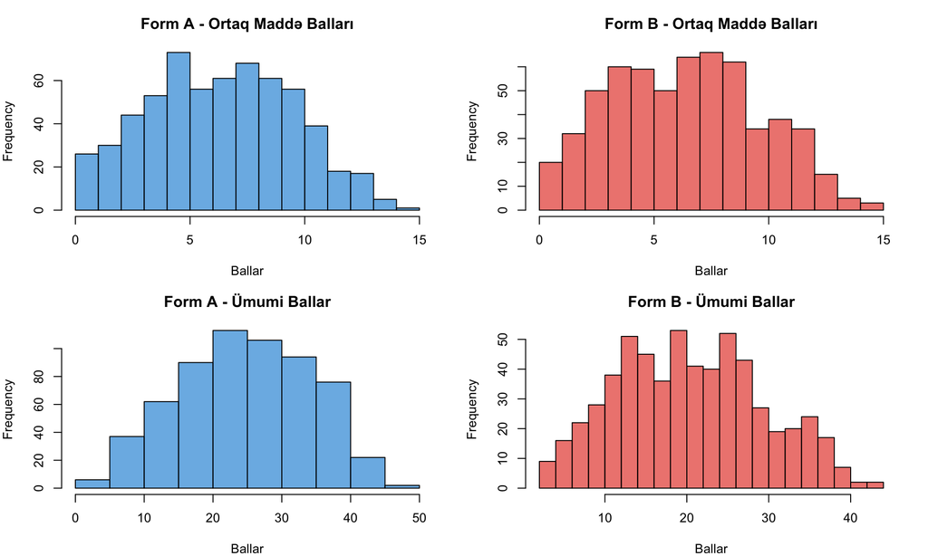

Ümumi Maddə Dizaynının Vizual Təhlili

```r
# Ümumi maddə dizaynının vizuallaşdırılması
par(mfrow = c(2, 2), mar = c(4, 4, 3, 2))

# 1. Ortaq maddə paylanması
hist(form_A_common_scores[observed_A], breaks = 15, col = adjustcolor(colors_custom[1], alpha.f = 0.7),
     main = "Form A - Ortaq Maddə Balları", xlab = "Ballar")
hist(form_B_common_scores[observed_B], breaks = 15, col = adjustcolor(colors_custom[2], alpha.f = 0.7),
     main = "Form B - Ortaq Maddə Balları", xlab = "Ballar")

# 2. Ümumi bal paylanması
hist(form_A_total_scores[observed_A], breaks = 15, col = adjustcolor(colors_custom[1], alpha.f = 0.7),
     main = "Form A - Ümumi Ballar", xlab = "Ballar")
hist(form_B_total_scores[observed_B], breaks = 15, col = adjustcolor(colors_custom[2], alpha.f = 0.7),
     main = "Form B - Ümumi Ballar", xlab = "Ballar")
```

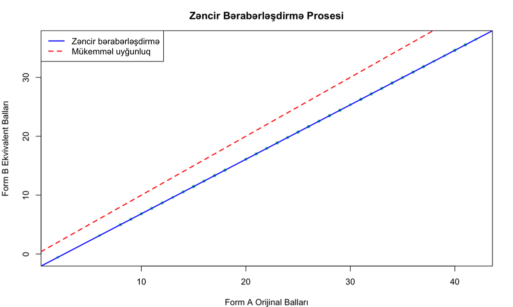

Ümumi Maddə Dizaynının Vizual Təhlili

```r
# Zəncir bərabərləşdirmə prosesinin vizuallaşdırılması
par(mfrow = c(1, 1))
# Chain transformed scores-u düzgün hesablayaq
chain_transformed_sample <- equate_score_chain(form_A_total_scores[observed_A][1:min(100, length(observed_A))])
original_sample <- form_A_total_scores[observed_A][1:length(chain_transformed_sample)]

plot(original_sample, chain_transformed_sample,
     xlab = "Form A Orijinal Balları", ylab = "Form B Ekvivalent Balları",
     main = "Zəncir Bərabərləşdirmə Prosesi",
     col = adjustcolor(colors_custom[3], alpha.f = 0.6), pch = 16, cex = 0.8)
abline(0, 1, col = "red", lty = 2, lwd = 2)
abline(chain_eq$intercept, chain_eq$slope, col = "blue", lwd = 2)
legend("topleft",
       c("Zəncir bərabərləşdirmə", "Mükemməl uyğunluq"),
       col = c("blue", "red"), lty = c(1, 2), lwd = 2)
```

# 4 Ümumi Şəxs Dizaynı (Common Person Design)

## 4.1 Metodun Əsasları

Ümumi şəxs dizaynında **eyni şagirdlər hər iki testi verir**. Bu metodun əsas üstünlüyü odur ki, şagird qabiliyyətləri sabit qaldığı üçün bərabərləşdirmə daha dəqiq olur.

### 4.1.1 Praktik Məhdudiyyətlər

Ümumi Şəxs Dizaynının Məhdudiyyətləri və Həll Yolları

| Məhdudiyyət | Təsir | Həll.Yolları |
| --- | --- | --- |
| Vaxt məhdudiyyəti | İki test çox vaxt aparır | Qısa testlər, ara verilməsi |
| Yorğunluq effekti | İkinci testdə performans azalır | Ardıcıllığın dəyişdirilməsi |
| Öyrənmə effekti | Birinci test ikinci testə kömək edir | Paralel formalar istifadəsi |
| Test təhlükəsizliği | Eyni şəxslər müxtəlif sualları görür | Təhlükəsizlik protokolları |

## 4.2 R-də Simulyasiya

### 4.2.1 Realistik Effektlərin Modelləşdirilməsi

```r
# Ümumi şəxs dizaynı simulyasiyası
set.seed(789)

# Parametrlər
n_common_persons <- 300  # Hər iki testi verən şagirdlər
n_only_A <- 400          # Yalnız Form A verən şagirdlər
n_only_B <- 350          # Yalnız Form B verən şagirdlər

total_students_cp <- n_common_persons + n_only_A + n_only_B

# Şagird qabiliyyətlərini yaradın
abilities_cp <- rnorm(total_students_cp, mean = 0, sd = 1)

# Şagird məlumatlarını yaradın
students_cp <- data.frame(
  student_id = 1:total_students_cp,
  ability = abilities_cp,
  test_pattern = c(
    rep("Both", n_common_persons),
    rep("Only_A", n_only_A),
    rep("Only_B", n_only_B)
  )
)

cat("=== Ümumi Şəxs Dizaynı Strukturu ===\n")
```

```
## === Ümumi Şəxs Dizaynı Strukturu ===
```

```r
cat("Hər iki testi verən şagirdlər:", n_common_persons, "\n")
```

```
## Hər iki testi verən şagirdlər: 300
```

```r
cat("Yalnız Form A verən şagirdlər:", n_only_A, "\n")
```

```
## Yalnız Form A verən şagirdlər: 400
```

```r
cat("Yalnız Form B verən şagirdlər:", n_only_B, "\n")
```

```
## Yalnız Form B verən şagirdlər: 350
```

```r
cat("Ümumi şagird sayı:", total_students_cp, "\n")
```

```
## Ümumi şagird sayı: 1050
```

### 4.2.2 Praktik Effektlərin Tətbiqi

```r
# Test parametrləri (bir az fərqli çətinlik)
form_A_params <- list(difficulty = 0.0, discrimination = 1.0)
form_B_params <- list(difficulty = 0.15, discrimination = 1.05)

# Əlavə effektlər (praktik faktorlar)
learning_effect <- 0.1      # Öyrənmə effekti (standart sapma vahidi)
fatigue_effect <- -0.05     # Yorğunluq effekti
practice_variance <- 0.1    # Praktik effekt variabtlığı

# Test ballarını hesablayın
calculate_cp_score <- function(ability, difficulty, discrimination,
                              is_second_test = FALSE, n_items = 50) {
  # Əlavə effektləri tətbiq edin
  adjusted_ability <- ability
  if (is_second_test) {
    # Öyrənmə və yorğunluq effektlərinin kombinasiyası
    practice_effect <- rnorm(1, learning_effect + fatigue_effect, practice_variance)
    adjusted_ability <- ability + practice_effect
  }

  # Logistik model
  prob_correct <- 1 / (1 + exp(-discrimination * (adjusted_ability - difficulty)))
  raw_score <- rbinom(1, n_items, prob_correct)
  scaled_score <- round((raw_score / n_items) * 100, 0)

  return(scaled_score)
}

# Balları hesablayın
students_cp$form_A_score <- NA
students_cp$form_B_score <- NA

for (i in 1:total_students_cp) {
  pattern <- students_cp$test_pattern[i]
  ability <- students_cp$ability[i]

  if (pattern %in% c("Both", "Only_A")) {
    students_cp$form_A_score[i] <- calculate_cp_score(
      ability, form_A_params$difficulty, form_A_params$discrimination, FALSE
    )
  }

  if (pattern %in% c("Both", "Only_B")) {
    is_second <- (pattern == "Both")  # Both qrupunda B ikinci testdir
    students_cp$form_B_score[i] <- calculate_cp_score(
      ability, form_B_params$difficulty, form_B_params$discrimination, is_second
    )
  }
}

# Qrupları ayırın
common_persons <- students_cp[students_cp$test_pattern == "Both", ]
only_A_persons <- students_cp[students_cp$test_pattern == "Only_A", ]
only_B_persons <- students_cp[students_cp$test_pattern == "Only_B", ]

# Ümumi şəxslərdə korelasiya
correlation_AB <- cor(common_persons$form_A_score, common_persons$form_B_score)
cat("\n=== Ümumi Şəxslər Analizi ===\n")
```

```
##
## === Ümumi Şəxslər Analizi ===
```

```r
cat("Form A və Form B arasında korelasiya:", round(correlation_AB, 3), "\n")
```

```
## Form A və Form B arasında korelasiya: 0.899
```

```r
# Praktik effektlərin təhlili
mean_diff_forms <- mean(common_persons$form_B_score) - mean(common_persons$form_A_score)
cat("Ortalama bal fərqi (B - A):", round(mean_diff_forms, 2), "\n")
```

```
## Ortalama bal fərqi (B - A): -2.3
```

```r
paired_t_test <- t.test(common_persons$form_B_score, common_persons$form_A_score,
                       paired = TRUE)
cat("Paired t-test p-value:", round(paired_t_test$p.value, 4), "\n")
```

```
## Paired t-test p-value: 1e-04
```

```r
if (paired_t_test$p.value < 0.05) {
  cat("⚠️  Praktik effektlər məna fərqi yaradıb!\n")
} else {
  cat("✅ Praktik effektlər əhəmiyyətli deyil\n")
}
```

```
## ⚠️  Praktik effektlər məna fərqi yaradıb!
```

### 4.2.3 Bərabərləşdirmə və Analiz

```r
# Bərabərləşdirmə (Form B → Form A ümumi şəxslər əsasında)
eq_common_person <- linear_equating(common_persons$form_B_score, common_persons$form_A_score)

cat("\n=== Ümumi Şəxs Bərabərləşdirmə ===\n")
```

```
##
## === Ümumi Şəxs Bərabərləşdirmə ===
```

```r
cat("Slope (b):", round(eq_common_person$slope, 4), "\n")
```

```
## Slope (b): 0.983
```

```r
cat("Intercept (a):", round(eq_common_person$intercept, 2), "\n")
```

```
## Intercept (a): 3.09
```

```r
# Bərabərləşdirmə funksiyası
equate_score_cp <- function(x) {
  return(eq_common_person$intercept + eq_common_person$slope * x)
}

# Nümunə transformasiyalar
sample_scores_B_cp <- c(65, 75, 85, 95)
cp_equated_scores <- equate_score_cp(sample_scores_B_cp)

transformation_table_cp <- data.frame(
  "Form B Balı" = sample_scores_B_cp,
  "Form A Ekvivalenti" = round(cp_equated_scores, 1),
  "Düzəliş" = round(cp_equated_scores - sample_scores_B_cp, 1)
)

kable(transformation_table_cp,
      caption = "Ümumi Şəxs Bərabərləşdirmə Nümunələri",
      align = c("c", "c", "c"))
```

Ümumi Şəxs Bərabərləşdirmə Nümunələri

| Form.B.Balı | Form.A.Ekvivalenti | Düzəliş |
| --- | --- | --- |
| 65 | 67.0 | 2.0 |
| 75 | 76.8 | 1.8 |
| 85 | 86.6 | 1.6 |
| 95 | 96.5 | 1.5 |

### 4.2.4 Qabiliyyət Qruplarına Görə Təhlil

```r
# Praktik effektlərin qabiliyyət səviyyəsinə görə təhlili
effect_analysis <- function(common_data) {
  # Qabiliyyət qrupları yaradın
  ability_groups <- cut(common_data$ability,
                       breaks = quantile(common_data$ability, c(0, 0.33, 0.67, 1)),
                       labels = c("Aşağı", "Orta", "Yüksək"),
                       include.lowest = TRUE)

  effect_results <- data.frame(
    Qabiliyyət_Qrupu = levels(ability_groups),
    Form_A_Ortalama = NA,
    Form_B_Ortalama = NA,
    Fərq_B_minus_A = NA,
    Korelasiya = NA,
    Şagird_Sayı = NA
  )

  for (i in 1:length(levels(ability_groups))) {
    group_data <- common_data[ability_groups == levels(ability_groups)[i], ]

    if (nrow(group_data) > 5) {  # Minimum nümunə ölçüsü
      effect_results$Form_A_Ortalama[i] <- round(mean(group_data$form_A_score), 2)
      effect_results$Form_B_Ortalama[i] <- round(mean(group_data$form_B_score), 2)
      effect_results$Fərq_B_minus_A[i] <- round(mean(group_data$form_B_score - group_data$form_A_score), 2)
      effect_results$Korelasiya[i] <- round(cor(group_data$form_A_score, group_data$form_B_score), 3)
      effect_results$Şagird_Sayı[i] <- nrow(group_data)
    }
  }

  return(effect_results)
}

effect_analysis_results <- effect_analysis(common_persons)

cat("\n=== Qabiliyyət Qruplarına Görə Effekt Təhlili ===\n")
```

```
##
## === Qabiliyyət Qruplarına Görə Effekt Təhlili ===
```

```r
kable(effect_analysis_results,
      caption = "Praktik Effektlərin Qabiliyyət Qruplarına Görə Təhlili",
      align = c("l", "c", "c", "c", "c", "c"))
```

Praktik Effektlərin Qabiliyyət Qruplarına Görə Təhlili

| Qabiliyyət_Qrupu | Form_A_Ortalama | Form_B_Ortalama | Fərq_B_minus_A | Korelasiya | Şagird_Sayı |
| --- | --- | --- | --- | --- | --- |
| Aşağı | 23.72 | 22.16 | -1.56 | 0.668 | 99 |
| Orta | 50.51 | 46.76 | -3.75 | 0.462 | 102 |
| Yüksək | 72.14 | 70.59 | -1.56 | 0.578 | 99 |

### 4.2.5 Vizuallaşdırma

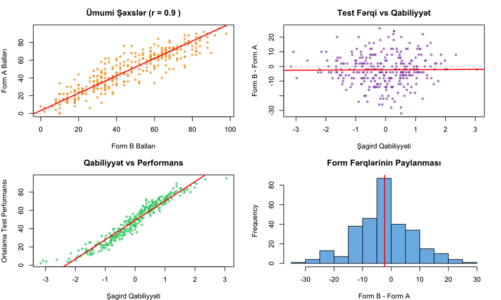

Ümumi Şəxs Dizaynının Vizual Təhlili

```r
# Ümumi şəxslərdə scatter plot və effekt təhlili
par(mfrow = c(2, 2), mar = c(4, 4, 3, 2))

# 1. Ümumi şəxslərdə scatter plot
plot(common_persons$form_B_score, common_persons$form_A_score,
     xlab = "Form B Balları", ylab = "Form A Balları",
     main = paste("Ümumi Şəxslər (r =", round(correlation_AB, 2), ")"),
     col = adjustcolor(colors_custom[4], alpha.f = 0.7), pch = 16, cex = 0.8)

# Bərabərləşdirmə xəttini əlavə edin
abline(eq_common_person$intercept, eq_common_person$slope, col = "red", lwd = 2)
abline(0, 1, col = "gray", lty = 2)

# 2. Form fərqləri vs qabiliyyət
plot(common_persons$ability, common_persons$form_B_score - common_persons$form_A_score,
     xlab = "Şagird Qabiliyyəti", ylab = "Form B - Form A",
     main = "Test Fərqi vs Qabiliyyət",
     col = adjustcolor(colors_custom[5], alpha.f = 0.7), pch = 16, cex = 0.8)
abline(h = 0, col = "gray", lty = 2)

# Reqressiya xətti əlavə edin
lm_fit <- lm((form_B_score - form_A_score) ~ ability, data = common_persons)
abline(lm_fit, col = "red", lwd = 2)

# 3. Qabiliyyət vs ortalama performans
avg_performance <- (common_persons$form_A_score + common_persons$form_B_score) / 2
plot(common_persons$ability, avg_performance,
     xlab = "Şagird Qabiliyyəti", ylab = "Ortalama Test Performansı",
     main = "Qabiliyyət vs Performans",
     col = adjustcolor(colors_custom[3], alpha.f = 0.7), pch = 16, cex = 0.8)

# Reqressiya xətti
lm_fit2 <- lm(avg_performance ~ common_persons$ability)
abline(lm_fit2, col = "red", lwd = 2)

# 4. Paired difference histogram
hist(common_persons$form_B_score - common_persons$form_A_score,
     breaks = 15, col = adjustcolor(colors_custom[1], alpha.f = 0.7),
     main = "Form Fərqlərinin Paylanması",
     xlab = "Form B - Form A")
abline(v = mean_diff_forms, col = "red", lwd = 2)
```

# 5 Dizayn Metodlarının Müqayisəsi

## 5.1 Hərtərəfli Müqayisə

```r
# Üç metodun nəticələrini müqayisə edin
comparison_results <- data.frame(
  Metod = c("Təsadüfi Qruplar", "Ümumi Maddə (Zəncir)", "Ümumi Şəxs"),
  Slope_b = c(
    round(eq_params_rg$slope, 4),
    round(chain_eq$slope, 4),
    round(eq_common_person$slope, 4)
  ),
  Intercept_a = c(
    round(eq_params_rg$intercept, 2),
    round(chain_eq$intercept, 2),
    round(eq_common_person$intercept, 2)
  ),
  Nümunə_Ölçüsü = c(
    nrow(group_A) + nrow(group_B),
    length(observed_A) + length(observed_B),
    nrow(common_persons)
  ),
  Korelasiya = c(
    NA,  # Təsadüfi qruplarda korelasiya yoxdur
    round(common_correlation, 3),
    round(correlation_AB, 3)
  ),
  Dizayn_Keyfiyyəti = c(
    design_quality_rg,
    "Yaxşı",
    "Çox Yaxşı"
  )
)

kable(comparison_results,
      caption = "Dizayn Metodlarının Hərtərəfli Müqayisəsi",
      align = c("l", "c", "c", "c", "c", "l"))
```

Dizayn Metodlarının Hərtərəfli Müqayisəsi

| Metod | Slope_b | Intercept_a | Nümunə_Ölçüsü | Korelasiya | Dizayn_Keyfiyyəti |
| --- | --- | --- | --- | --- | --- |
| Təsadüfi Qruplar | 0.9537 | -3.72 | 2000 | NA | Yaxşı |
| Ümumi Maddə (Zəncir) | 0.9250 | -2.41 | 1200 | 0.717 | Yaxşı |
| Ümumi Şəxs | 0.9830 | 3.09 | 300 | 0.899 | Çox Yaxşı |

```r
# Transformasiya fərqlərini müqayisə edin
test_scores <- seq(60, 90, 10)
rg_transformed <- equate_score_rg(test_scores)
chain_transformed <- equate_score_chain(test_scores)
cp_transformed <- equate_score_cp(test_scores)

transformation_comparison <- data.frame(
  Orijinal_Bal = test_scores,
  Təsadüfi_Qruplar = round(rg_transformed, 1),
  Ümumi_Maddə = round(chain_transformed, 1),
  Ümumi_Şəxs = round(cp_transformed, 1)
)

# Fərqləri hesablayın
transformation_comparison$RG_vs_CI <- round(transformation_comparison$Təsadüfi_Qruplar -
                                          transformation_comparison$Ümumi_Maddə, 1)
transformation_comparison$RG_vs_CP <- round(transformation_comparison$Təsadüfi_Qruplar -
                                          transformation_comparison$Ümumi_Şəxs, 1)
transformation_comparison$CI_vs_CP <- round(transformation_comparison$Ümumi_Maddə -
                                          transformation_comparison$Ümumi_Şəxs, 1)

cat("\n=== Transformasiya Müqayisəsi ===\n")
```

```
##
## === Transformasiya Müqayisəsi ===
```

```r
kable(transformation_comparison,
      caption = "Müxtəlif Dizaynların Transformasiya Nəticələri",
      align = "c")
```

Müxtəlif Dizaynların Transformasiya Nəticələri

| Orijinal_Bal | Təsadüfi_Qruplar | Ümumi_Maddə | Ümumi_Şəxs | RG_vs_CI | RG_vs_CP | CI_vs_CP |
| --- | --- | --- | --- | --- | --- | --- |
| 60 | 53.5 | 53.1 | 62.1 | 0.4 | -8.6 | -9.0 |
| 70 | 63.0 | 62.3 | 71.9 | 0.7 | -8.9 | -9.6 |
| 80 | 72.6 | 71.6 | 81.7 | 1.0 | -9.1 | -10.1 |
| 90 | 82.1 | 80.8 | 91.6 | 1.3 | -9.5 | -10.8 |

## 5.2 Qərar Matrisi

```r
# Qərar matrisi yaradın
decision_matrix <- data.frame(
  Meyar = c(
    "Test Təhlükəsizliyi",
    "Vaxt Səmərəliliyi",
    "Nümunə Ölçüsü Tələbi",
    "Statistik Dəqiqlik",
    "Praktik Tətbiq",
    "Məlumat Keyfiyyəti",
    "Metodoloji Sadəlik",
    "Təsadüfi Xəta",
    "Sistematik Xəta Riski"
  ),
  Təsadüfi_Qruplar = c(
    "Yüksək ⭐⭐⭐", "Yüksək ⭐⭐⭐", "Böyük ❌", "Orta ⭐⭐",
    "Asan ⭐⭐⭐", "Orta ⭐⭐", "Sadə ⭐⭐⭐", "Orta ⭐⭐", "Orta ⭐⭐"
  ),
  Ümumi_Maddə = c(
    "Orta ⭐⭐", "Orta ⭐⭐", "Orta ⭐⭐", "Yüksək ⭐⭐⭐",
    "Orta ⭐⭐", "Yüksək ⭐⭐⭐", "Mürəkkəb ❌", "Aşağı ⭐⭐⭐", "Aşağı ⭐⭐⭐"
  ),
  Ümumi_Şəxs = c(
    "Aşağı ❌", "Aşağı ❌", "Kiçik ⭐⭐⭐", "Ən Yüksək ⭐⭐⭐",
    "Çətin ❌", "Ən Yüksək ⭐⭐⭐", "Sadə ⭐⭐⭐", "Ən Aşağı ⭐⭐⭐", "Orta ⭐⭐"
  )
)

kable(decision_matrix,
      caption = "Dizayn Seçimi üçün Qərar Matrisi",
      align = c("l", "c", "c", "c"))
```

Dizayn Seçimi üçün Qərar Matrisi

| Meyar | Təsadüfi_Qruplar | Ümumi_Maddə | Ümumi_Şəxs |
| --- | --- | --- | --- |
| Test Təhlükəsizliyi | Yüksək ⭐⭐⭐ | Orta ⭐⭐ | Aşağı ❌ |
| Vaxt Səmərəliliyi | Yüksək ⭐⭐⭐ | Orta ⭐⭐ | Aşağı ❌ |
| Nümunə Ölçüsü Tələbi | Böyük ❌ | Orta ⭐⭐ | Kiçik ⭐⭐⭐ |
| Statistik Dəqiqlik | Orta ⭐⭐ | Yüksək ⭐⭐⭐ | Ən Yüksək ⭐⭐⭐ |
| Praktik Tətbiq | Asan ⭐⭐⭐ | Orta ⭐⭐ | Çətin ❌ |
| Məlumat Keyfiyyəti | Orta ⭐⭐ | Yüksək ⭐⭐⭐ | Ən Yüksək ⭐⭐⭐ |
| Metodoloji Sadəlik | Sadə ⭐⭐⭐ | Mürəkkəb ❌ | Sadə ⭐⭐⭐ |
| Təsadüfi Xəta | Orta ⭐⭐ | Aşağı ⭐⭐⭐ | Ən Aşağı ⭐⭐⭐ |
| Sistematik Xəta Riski | Orta ⭐⭐ | Aşağı ⭐⭐⭐ | Orta ⭐⭐ |

# 6 NEAT Dizaynı və Hibrid Metodlar

## 6.1 NEAT Dizaynının Xüsusiyyətləri

**NEAT (Non-Equivalent Anchor Test)** dizaynı **təsadüfi qruplar + ümumi maddələrin** kombinasiyasıdır və müasir böyük miqyaslı testlərdə ən çox istifadə olunan metoddur.

```r
# NEAT dizaynı - ən çox istifadə olunan hibrid metod
simulate_NEAT_design <- function() {
  set.seed(999)

  # Parametrlər
  n_students_neat <- 2000
  n_common_items <- 20
  n_unique_A <- 30
  n_unique_B <- 25

  # Şagird qabiliyyətləri
  abilities_neat <- rnorm(n_students_neat, 0, 1)

  # Təsadüfi qrup təyinatı
  group_assignment <- sample(c("Form_A", "Form_B"), n_students_neat, replace = TRUE)

  # Test strukturu simulyasiyası (sadələşdirilmiş)
  students_neat <- data.frame(
    student_id = 1:n_students_neat,
    ability = abilities_neat,
    assigned_form = group_assignment
  )

  # Balları hesablayın (IRT əsaslı)
  for (i in 1:n_students_neat) {
    ability <- students_neat$ability[i]

    if (students_neat$assigned_form[i] == "Form_A") {
      # Form A: Ortaq maddələr + Unikal maddələr
      common_score <- rbinom(1, n_common_items, plogis(ability - 0))
      unique_score <- rbinom(1, n_unique_A, plogis(ability - (-0.1)))
      students_neat$total_score[i] <- common_score + unique_score
      students_neat$common_score[i] <- common_score
    } else {
      # Form B: Ortaq maddələr + Unikal maddələr
      common_score <- rbinom(1, n_common_items, plogis(ability - 0))
      unique_score <- rbinom(1, n_unique_B, plogis(ability - 0.15))
      students_neat$total_score[i] <- common_score + unique_score
      students_neat$common_score[i] <- common_score
    }
  }

  return(students_neat)
}

neat_data <- simulate_NEAT_design()

# Qrupları ayırın
neat_A <- neat_data[neat_data$assigned_form == "Form_A", ]
neat_B <- neat_data[neat_data$assigned_form == "Form_B", ]

cat("=== NEAT Dizayn Strukturu ===\n")
```

```
## === NEAT Dizayn Strukturu ===
```

```r
cat("Form A şagirdləri:", nrow(neat_A), "\n")
```

```
## Form A şagirdləri: 1017
```

```r
cat("Form B şagirdləri:", nrow(neat_B), "\n")
```

```
## Form B şagirdləri: 983
```

```r
cat("Ortaq maddələr hər iki qrupda mövcuddur\n")
```

```
## Ortaq maddələr hər iki qrupda mövcuddur
```

```r
cat("Form A ortalama ümumi bal:", round(mean(neat_A$total_score), 2), "\n")
```

```
## Form A ortalama ümumi bal: 25.44
```

```r
cat("Form B ortalama ümumi bal:", round(mean(neat_B$total_score), 2), "\n")
```

```
## Form B ortalama ümumi bal: 21.77
```

```r
cat("Form A ortalama ortaq bal:", round(mean(neat_A$common_score), 2), "\n")
```

```
## Form A ortalama ortaq bal: 9.84
```

```r
cat("Form B ortalama ortaq bal:", round(mean(neat_B$common_score), 2), "\n")
```

```
## Form B ortalama ortaq bal: 10.02
```

# 7 Real Dünya Tətbiqləri

## 7.1 Ssenari Əsaslı Tövsiyələr

```r
# Müxtəlif ssenarilar üçün dizayn tövsiyələri
scenarios <- data.frame(
  Ssenari = c(
    "SAT/YÖS növü imtahan",
    "İngilis dili sertifikatı",
    "Tibb fakültəsi qəbul",
    "İş yerində performans testi",
    "Məktəb yetkin testləri",
    "Kompüter adaptiv test",
    "Xüsusi ehtiyaclı şagirdlər",
    "Beynəlxalq müqayisə (PISA)",
    "Online vs offline test",
    "Klinik diaqnostik test"
  ),
  Tövsiyə_Olunan_Dizayn = c(
    "Təsadüfi Qruplar",
    "Ümumi Maddə",
    "NEAT (Hibrid)",
    "Ümumi Şəxs",
    "Ümumi Maddə",
    "IRT əsaslı hibrid",
    "Ümumi Şəxs",
    "Ümumi Maddə",
    "Təsadüfi Qruplar",
    "Ümumi Şəxs"
  ),
  Əsas_Səbəb = c(
    "Böyük həcm, təhlükəsizlik",
    "Standart sertifikat, dəqiqlik",
    "Təhlükəsizlik + dəqiqlik",
    "Kiçik qrup, dəqiq ölçmə",
    "Pedaqoji məqsədlər",
    "Adaptiv alqoritm tələbi",
    "Fərdi yanaşma tələbi",
    "Ölkələr arası müqayisə",
    "Texniki məhdudiyyətlər",
    "Yüksək dəqiqlik tələbi"
  ),
  Prioritet = c("Yüksək", "Orta", "Yüksək", "Aşağı", "Orta",
                "Yüksək", "Aşağı", "Yüksək", "Orta", "Aşağı")
)

kable(scenarios,
      caption = "Real Ssenarilar üçün Dizayn Tövsiyələri",
      align = c("l", "l", "l", "c"))
```

Real Ssenarilar üçün Dizayn Tövsiyələri

| Ssenari | Tövsiyə_Olunan_Dizayn | Əsas_Səbəb | Prioritet |
| --- | --- | --- | --- |
| SAT/YÖS növü imtahan | Təsadüfi Qruplar | Böyük həcm, təhlükəsizlik | Yüksək |
| İngilis dili sertifikatı | Ümumi Maddə | Standart sertifikat, dəqiqlik | Orta |
| Tibb fakültəsi qəbul | NEAT (Hibrid) | Təhlükəsizlik + dəqiqlik | Yüksək |
| İş yerində performans testi | Ümumi Şəxs | Kiçik qrup, dəqiq ölçmə | Aşağı |
| Məktəb yetkin testləri | Ümumi Maddə | Pedaqoji məqsədlər | Orta |
| Kompüter adaptiv test | IRT əsaslı hibrid | Adaptiv alqoritm tələbi | Yüksək |
| Xüsusi ehtiyaclı şagirdlər | Ümumi Şəxs | Fərdi yanaşma tələbi | Aşağı |
| Beynəlxalq müqayisə (PISA) | Ümumi Maddə | Ölkələr arası müqayisə | Yüksək |
| Online vs offline test | Təsadüfi Qruplar | Texniki məhdudiyyətlər | Orta |
| Klinik diaqnostik test | Ümumi Şəxs | Yüksək dəqiqlik tələbi | Aşağı |

## 7.2 Keyfiyyət Qiymətləndirmə Metrikları

```r
# Dizayn keyfiyyətini qiymətləndirmə metrikları
evaluate_design_quality <- function(design_name, equating_params, sample_size,
                                   correlation = NA, anchor_proportion = NA) {

  # equating_params strukturunu yoxlayın və uyğunlaşdırın
  if (design_name == "Common Item" && "step1" %in% names(equating_params)) {
    # Chain equating üçün step1 istifadə edin
    sd_x <- equating_params$step1$sd_x
  } else {
    sd_x <- equating_params$sd_x
  }

  # Təxmini standart xəta hesablaması (Brown et al., 2007 formulları)
  if (design_name == "Random Groups") {
    se_estimate <- sqrt(2 / sample_size) * sd_x
  } else if (design_name == "Common Item") {
    # Anchor keyfiyyətindən asılıdır
    if (!is.na(anchor_proportion)) {
      se_estimate <- sqrt(1 / (sample_size * anchor_proportion)) * sd_x
    } else {
      se_estimate <- sqrt(3 / sample_size) * sd_x  # Default təxmin
    }
  } else if (design_name == "Common Person") {
    if (!is.na(correlation)) {
      se_estimate <- sqrt((2 * (1 - correlation^2)) / sample_size) * sd_x
    } else {
      se_estimate <- sqrt(2 / sample_size) * sd_x  # Default təxmin
    }
  } else {
    se_estimate <- sqrt(2 / sample_size) * sd_x  # Default
  }

  # NA yoxlaması
  if (is.na(se_estimate) || !is.finite(se_estimate)) {
    se_estimate <- 999  # Çox böyük dəyər
  }

  # Keyfiyyət qiymətləndirməsi
  quality_grade <- ifelse(se_estimate < 2, "A",
                         ifelse(se_estimate < 3, "B", "C"))

  return(list(
    design = design_name,
    estimated_se = round(se_estimate, 3),
    sample_size = sample_size,
    quality_grade = quality_grade
  ))
}

# Hər üç dizayn üçün keyfiyyət qiymətləndirməsi
quality_rg <- evaluate_design_quality(
  "Random Groups", eq_params_rg,
  nrow(group_A) + nrow(group_B)
)

quality_ci <- evaluate_design_quality(
  "Common Item", chain_eq,
  length(observed_A) + length(observed_B),
  anchor_proportion = 0.3
)

quality_cp <- evaluate_design_quality(
  "Common Person", eq_common_person,
  nrow(common_persons),
  correlation = correlation_AB
)

# Nəticələri göstər
quality_summary <- data.frame(
  Dizayn = c(quality_rg$design, quality_ci$design, quality_cp$design),
  Standart_Xəta = c(quality_rg$estimated_se, quality_ci$estimated_se, quality_cp$estimated_se),
  Nümunə_Ölçüsü = c(quality_rg$sample_size, quality_ci$sample_size, quality_cp$sample_size),
  Keyfiyyət_Qiymət = c(quality_rg$quality_grade, quality_ci$quality_grade, quality_cp$quality_grade)
)

cat("\n=== Dizayn Keyfiyyət Qiymətləndirməsi ===\n")
```

```
##
## === Dizayn Keyfiyyət Qiymətləndirməsi ===
```

```r
kable(quality_summary,
      caption = "Müxtəlif Dizaynların Keyfiyyət Göstəriciləri",
      align = c("l", "c", "c", "c"))
```

Müxtəlif Dizaynların Keyfiyyət Göstəriciləri

| Dizayn | Standart_Xəta | Nümunə_Ölçüsü | Keyfiyyət_Qiymət |
| --- | --- | --- | --- |
| Random Groups | 0.723 | 2000 | A |
| Common Item | 0.494 | 1200 | A |
| Common Person | 0.809 | 300 | A |

# 8 Ümumi Problemlər və Həll Yolları

## 8.1 Dizayn Seçimi Problemləri

```r
# Ümumi səhvlər və qarşısının alınması
common_mistakes <- data.frame(
  Səhv = c(
    "Kiçik nümunə ölçüsü",
    "Qruplar arası böyük fərqlər",
    "Zəif ortaq maddələr",
    "Dizayn qarışıqlığı",
    "Validasiya olmaması",
    "Dokumentasiya çatışmazlığı",
    "Praktik effektlərin nəzərə alınmaması",
    "Korelasiya təhlilinin olmaması"
  ),
  Nəticəsi = c(
    "Böyük standart xətalar",
    "Yanlış bərabərləşdirmə",
    "Etibarsız zəncir bərabərləşdirmə",
    "İnterpretasiya problemləri",
    "Bilinməyən xətalar",
    "Təkrar olunmazlıq",
    "Sistematik təhrif",
    "Dizayn keyfiyyətinin qiymətləndirilməməsi"
  ),
  Həlli = c(
    "Power analysis aparın",
    "Stratifikasiya istifadə edin",
    "Anchor analizi edin",
    "Standart protokollar tətbiq edin",
    "Bootstrap və residual analiz",
    "Structured reporting",
    "Counterbalancing tətbiq edin",
    "Reliability və validity yoxlaması"
  ),
  Təcili_Səviyyə = c("Yüksək", "Yüksək", "Orta", "Orta",
                     "Yüksək", "Aşağı", "Orta", "Orta")
)

kable(common_mistakes,
      caption = "Ümumi Səhvlər və Qarşısının Alınması",
      align = c("l", "l", "l", "c"))
```

Ümumi Səhvlər və Qarşısının Alınması

| Səhv | Nəticəsi | Həlli | Təcili_Səviyyə |
| --- | --- | --- | --- |
| Kiçik nümunə ölçüsü | Böyük standart xətalar | Power analysis aparın | Yüksək |
| Qruplar arası böyük fərqlər | Yanlış bərabərləşdirmə | Stratifikasiya istifadə edin | Yüksək |
| Zəif ortaq maddələr | Etibarsız zəncir bərabərləşdirmə | Anchor analizi edin | Orta |
| Dizayn qarışıqlığı | İnterpretasiya problemləri | Standart protokollar tətbiq edin | Orta |
| Validasiya olmaması | Bilinməyən xətalar | Bootstrap və residual analiz | Yüksək |
| Dokumentasiya çatışmazlığı | Təkrar olunmazlıq | Structured reporting | Aşağı |
| Praktik effektlərin nəzərə alınmaması | Sistematik təhrif | Counterbalancing tətbiq edin | Orta |
| Korelasiya təhlilinin olmaması | Dizayn keyfiyyətinin qiymətləndirilməməsi | Reliability və validity yoxlaması | Orta |

## 8.2 Praktik Həll Yolları

```r
# Praktik həll strategiyaları
solution_strategies <- data.frame(
  Problem_Kateqoriyası = c(
    "Nümunə Ölçüsü",
    "Dizayn Seçimi",
    "Keyfiyyət Nəzarəti",
    "Texniki Tətbiq",
    "Statistik Validasiya"
  ),
  Minimum_Tələblər = c(
    "n ≥ 200 (RG), n ≥ 300 (CI), n ≥ 100 (CP)",
    "Məqsədə uyğun seçim",
    "Çoxlu yoxlama nöqtəsi",
    "R/Python/SPSS",
    "Bootstrap, Resampling"
  ),
  Tövsiyə_Edilən = c(
    "n ≥ 500 (RG), n ≥ 600 (CI), n ≥ 200 (CP)",
    "Hibrid yanaşma",
    "Avtomatlaşdırılmış pipeline",
    "Specialized software",
    "Bayesian methods"
  ),
  Məlumat_Mənbəyi = c(
    "Kolen & Brennan (2014)",
    "Holland & Dorans (2006)",
    "von Davier (2011)",
    "R Documentation",
    "Mislevy & Sheehan (1989)"
  )
)

kable(solution_strategies,
      caption = "Praktik Həll Strategiyaları və Tövsiyələr",
      align = c("l", "l", "l", "l"))
```

Praktik Həll Strategiyaları və Tövsiyələr

| Problem_Kateqoriyası | Minimum_Tələblər | Tövsiyə_Edilən | Məlumat_Mənbəyi |
| --- | --- | --- | --- |
| Nümunə Ölçüsü | n ≥ 200 (RG), n ≥ 300 (CI), n ≥ 100 (CP) | n ≥ 500 (RG), n ≥ 600 (CI), n ≥ 200 (CP) | Kolen & Brennan (2014) |
| Dizayn Seçimi | Məqsədə uyğun seçim | Hibrid yanaşma | Holland & Dorans (2006) |
| Keyfiyyət Nəzarəti | Çoxlu yoxlama nöqtəsi | Avtomatlaşdırılmış pipeline | von Davier (2011) |
| Texniki Tətbiq | R/Python/SPSS | Specialized software | R Documentation |
| Statistik Validasiya | Bootstrap, Resampling | Bayesian methods | Mislevy & Sheehan (1989) |

# 9 Özünüyoxlama və Qiymətləndirmə

## 9.1 Əsas Suallar

### 9.1.1 Anlayış Yoxlaması

1. **Təsadüfi qruplar dizaynı** nə vaxt ən yaxşı seçimdir?
2. **Ümumi maddə dizaynında** zəncir bərabərləşdirmə nə üçün istifadə olunur?
3. **Ümumi şəxs dizaynının** əsas məhdudiyyətləri hansılardır?
4. NEAT dizaynı hansı iki metodun kombinasiyasıdır?
5. Kiçik nümunə ölçüsü dizayn seçiminə necə təsir edir?

### 9.1.2 Praktik Tapşırıqlar

```r
# Tapşırıq 1: Öz Simulyasiyanız
# Müxtəlif dizaynları simulyasiya edin və nəticələri müqayisə edin

set.seed(sizin_doğum_iliniz)  # Doğum ilinizi yazın

# 1.1 Təsadüfi qruplar simulyasiyası
rg_sim <- function(n1, n2, mean_diff = 0) {
  # Kodunuzu yazın
}

# 1.2 Ümumi maddə simulyasiyası
ci_sim <- function(n_common, n_unique_A, n_unique_B) {
  # Kodunuzu yazın
}

# 1.3 Ümumi şəxs simulyasiyası
cp_sim <- function(n_common, n_only_A, n_only_B) {
  # Kodunuzu yazın
}

# Tapşırıq 2: Real Məlumatlarla Təcrübə
# Əgər real test məlumatlarınız varsa:
# - Uyğun dizayn metodunu seçin
# - Bərabərləşdirmə aparın
# - Nəticələri validasiya edin

# Tapşırıq 3: Dizayn Seçimi Qərarı
# Verilmiş ssenari üçün ən yaxşı dizaynı seçin və əsaslandırın
```

# 10 Növbəti Addımlar və Dərs Əlaqələri

## 10.1 Dərs 5-ə Hazırlıq

Növbəti dərsdə **“Kernel Bərabərləşdirmə və Müasir Metodlar”** mövzusunu öyrənəcəyik:

- 🔬 Kernel bərabərləşdirmənin nəzəri əsasları
- 📊 Bandwidth seçimi və optimizasiya
- 🚀 Parametrik olmayan metodlar
- 🎯 Log-linear və digər hamarlaşdırma texnikaları

### 10.1.1 Hazırlıq Tövsiyələri

1. 📖 Bu dərsin materiallarını mütəmmim şəkildə nəzərdən keçirin
2. 💻 Hər üç dizayn metodunu praktik olaraq tətbiq edin
3. 🤔 Real həyat ssenarilərində dizayn seçimini düşünün
4. 📊 Məlumat vizuallaşdırması bacarıqlarınızı inkişaf etdirin

## 10.2 Əlavə Tədqiqat Mövzuları

```r
# İstəyənlər üçün əlavə araşdırma mövzuları

# 1. Bootstrap məlumat generasiyası
bootstrap_equating <- function(x, y, n_bootstrap = 1000) {
  # Bootstrap CI hesablaması
}

# 2. Bayesian bərabərləşdirmə
bayesian_equating <- function(x, y, prior_params) {
  # Bayesian yanaşma
}

# 3. Çoxölçülü testlər üçün dizayn
multivariate_design <- function(test_structure) {
  # Çoxölçülü dizayn simulyasiyası
}

# 4. Adaptiv test dizaynı
adaptive_design <- function(item_bank, stopping_rule) {
  # CAT üçün dizayn
}
```

# 11 Texniki Appendiks

## 11.1 Statistik Formullar

### 11.1.1 Lineer Bərabərləşdirmə

**Əsas transformasiya:** $Y = a + bX$

burada: - $b = \frac{SD_Y}{SD_X}$ (slope) - $a = \bar{Y} - b\bar{X}$ (intercept)

### 11.1.2 Zəncir Bərabərləşdirmə

**İki addımlı proses:** 1. $Z = a_1 + b_1 X$ (Total A → Common A)  
2. $Y = a_2 + b_2 Z$ (Common B → Total B)

**Kombinə edilmiş formula:** $Y = (a_2 + b_2 a_1) + (b_2 b_1)X$

### 11.1.3 Standart Xəta Təxminləri

**Təsadüfi qruplar üçün:** $SE \approx \sqrt{\frac{2}{n}} \cdot SD_X$

**Ümumi şəxs üçün:** $SE \approx \sqrt{\frac{2(1-r^2)}{n}} \cdot SD_X$

## 11.2 R Kodları Kitabxanası

```r
# Əsas funksiyalar kitabxanası

# 1. Sürətli dizayn müqayisəsi
compare_all_designs <- function(data_A, data_B, common_A = NULL, common_B = NULL) {
  results <- list()

  # Random Groups
  if (length(data_A) > 50 && length(data_B) > 50) {
    results$rg <- linear_equating(data_A, data_B)
  }

  # Common Item (əgər ortaq məlumat varsa)
  if (!is.null(common_A) && !is.null(common_B)) {
    results$ci <- chain_equating(data_A, data_B, common_A, common_B)
  }

  return(results)
}

# 2. Keyfiyyət yoxlama funksiyası
quality_check <- function(original_scores, equated_scores) {
  list(
    mean_preservation = abs(mean(equated_scores) - mean(original_scores)),
    sd_ratio = sd(equated_scores) / sd(original_scores),
    correlation = cor(original_scores, equated_scores),
    rmse = sqrt(mean((equated_scores - original_scores)^2))
  )
}

# 3. Vizuallaşdırma template
plot_equating_results <- function(x, y, equated_y, title = "Equating Results") {
  par(mfrow = c(1, 2))

  # Orijinal vs equated
  plot(x, equated_y, main = paste(title, "- Transformation"),
       xlab = "Original Scores", ylab = "Equated Scores")
  abline(0, 1, col = "red", lty = 2)

  # Residuals
  plot(x, equated_y - x, main = paste(title, "- Residuals"),
       xlab = "Original Scores", ylab = "Residuals")
  abline(h = 0, col = "red", lty = 2)
}

cat("✅ Kod kitabxanası hazırlanıldı!\n")
```

```
## ✅ Kod kitabxanası hazırlanıldı!
```

# 12 Dərsin Xülasəsi və Nəticələr

## 12.1 Əsas Öyrənilən Mövzular

Bu dərsdə aşağıdakı əsas mövzuları əhatə etdik:

✅ **Dizayn növləri** - Təsadüfi qruplar, ümumi maddə, ümumi şəxs  
✅ **Praktik tətbiq** - R-də hərtərəfli simulyasiya  
✅ **Keyfiyyət qiymətləndirmə** - Validasiya və metrik hesablaması  
✅ **Real ssenarilar** - Praktik tövsiyələr və seçim meyarları  
✅ **Problem həlli** - Ümumi səhvlər və qarşısının alınması

## 12.2 Praktiki Nəticələr

```r
cat("=== DƏRS NƏTİCƏLƏRİ ===\n\n")
```

```
## === DƏRS NƏTİCƏLƏRİ ===
```

```r
cat("📊 Yaradılmış simulyasiyalar:\n")
```

```
## 📊 Yaradılmış simulyasiyalar:
```

```r
cat("   - Təsadüfi qruplar dizaynı:", nrow(group_A) + nrow(group_B), "şagird\n")
```

```
##    - Təsadüfi qruplar dizaynı: 2000 şagird
```

```r
cat("   - Ümumi maddə dizaynı:", length(observed_A) + length(observed_B), "şagird\n")
```

```
##    - Ümumi maddə dizaynı: 1200 şagird
```

```r
cat("   - Ümumi şəxs dizaynı:", nrow(common_persons), "ümumi şəxs\n\n")
```

```
##    - Ümumi şəxs dizaynı: 300 ümumi şəxs
```

```r
cat("🎯 Əldə edilən bərabərləşdirmə parametrləri:\n")
```

```
## 🎯 Əldə edilən bərabərləşdirmə parametrləri:
```

```r
cat("   - RG slope:", round(eq_params_rg$slope, 4), "\n")
```

```
##    - RG slope: 0.9537
```

```r
cat("   - CI slope:", round(chain_eq$slope, 4), "\n")
```

```
##    - CI slope: 0.925
```

```r
cat("   - CP slope:", round(eq_common_person$slope, 4), "\n\n")
```

```
##    - CP slope: 0.983
```

```r
cat("📈 Keyfiyyət göstəriciləri:\n")
```

```
## 📈 Keyfiyyət göstəriciləri:
```

```r
cat("   - Ən yüksək korelasiya:", round(max(correlation_AB, common_correlation, na.rm = TRUE), 3), "\n")
```

```
##    - Ən yüksək korelasiya: 0.899
```

```r
cat("   - Ən aşağı standart xəta:", round(min(quality_summary$Standart_Xəta, na.rm = TRUE), 3), "\n\n")
```

```
##    - Ən aşağı standart xəta: 0.494
```

```r
# Məlumatları saxlayın
save(group_A, group_B, common_persons, chain_eq, eq_params_rg, eq_common_person,
     file = "lesson4_design_data.RData")
cat("💾 Məlumatlar lesson4_design_data.RData faylında saxlanıldı\n")
```

```
## 💾 Məlumatlar lesson4_design_data.RData faylında saxlanıldı
```

## 12.3 Tövsiyələr və Ən Yaxşı Praktikalar

### 12.3.1 🎯 Praktik Tövsiyələr

1. **Dizayn Seçimi**: Məqsədə və resurslara uyğun seçim edin
2. **Nümunə Ölçüsü**: Minimum tələblərə riayət edin
3. **Keyfiyyət Nəzarəti**: Müntəzəm yoxlamalar aparın
4. **Sənədləşdirmə**: Prosesin hər mərhələsini qeyd edin

### 12.3.2 📚 BÖYÜK MİQYASLI TESTLƏR üçün: Təsadüfi Qruplar Dizaynı

- Universitet qəbul imtahanları
- Milli standartlaşdırılmış testlər
- İş qabiliyyəti testləri

### 12.3.3 🔬 AKADEMIK TƏDQİQATLAR üçün: Ümumi Maddə Dizaynı

- Test inkişafı və validasiyası
- Müxtəlif dillərdə adaptasiya
- Longitudinal tədqiqatlar

### 12.3.4 🎯 YÜKSƏK DƏQİQLİK TƏLƏBİ üçün: Ümumi Şəxs Dizaynı

- Kiçik qrup diagnostik testləri
- Klinik qiymətləndirmələr
- Təlim effektivliyi ölçümü

# 13 İstinadlar və Əlavə Resurlar

## 13.1 Əsas Ədəbiyyat

1. **Kolen, M. J., & Brennan, R. L. (2014).** *Test Equating, Scaling, and Linking: Methods and Practices* (3rd ed.). Springer.
2. **Holland, P. W., & Dorans, N. J. (2006).** Linking and equating. In R. L. Brennan (Ed.), *Educational measurement* (4th ed., pp. 187-220).
3. **von Davier, A. A. (2011).** *Statistical models for test equating, scaling, and linking*. Springer.
4. **Dorans, N. J., Pommerich, M., & Holland, P. W. (Eds.). (2007).** *Linking and aligning scores and scales*. Springer.

## 13.2 R Paketləri və Sənədlər

```r
# Əsas paketlər
citation("equate")      # Albano, A. D. (2016). equate: An R package for observed-score linking and equating
citation("kequate")     # Andersson, B., et al. (2013). Kernel equating in R
citation("ggplot2")     # Wickham, H. (2016). ggplot2: Elegant Graphics for Data Analysis

# Paket sənədlərinə baxış
help(package = "equate")
vignette("equate")
browseVignettes("kequate")
```

## 13.3 Online Resurlar

- 🌐 **ETS Research**: https://www.ets.org/research/
- 📚 **CRAN Psychometrics**: https://cran.r-project.org/web/views/Psychometrics.html
- 💻 **GitHub**: Test equating repositories və kod nümunələri

*Bu dərs materialı açıq mənbə prinsiplərinə uyğun olaraq hazırlanmışdır və təhsil məqsədləri üçün sərbəst istifadə edilə bilər. Test bərabərləşdirmə sahəsində praktik bilgilərinizi artırmaq üçün növbəti dərslərdə daha mürəkkəb metodları öyrənəcəksiniz.*